# Reproducible Research: Peer Assessment 1

## Loading and preprocessing the data

We need to load the data from the file. So I used the variable f to store the file location of the csv and loaded it in with the read.csv function.

```r
f = "./Data/activity.csv"
data = read.csv(f, colClasses = c("numeric", "character", "numeric"))
```

## What is mean total number of steps taken per day?

To get a histogram of the total number of steps we must sum all the number of steps by day

```r
stepsPerDay = aggregate(data$steps,by=list(data$date),sum,na.rm=TRUE)
```

Now we can turn this into a histogram. First we want to give column names, however.

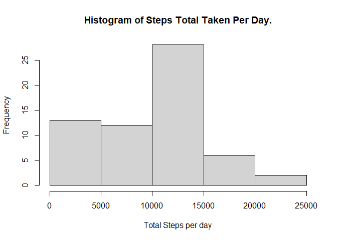

```r
colnames(stepsPerDay)=c("Date", "sum")
hist(stepsPerDay$sum, xlab="Total Steps per day", main="Histogram of Steps Total Taken Per Day.")
```

To obtain the mean and median of these sums we can use this code:

```r
mean(stepsPerDay$sum)
```

```
## [1] 9354.23
```

```r
median(stepsPerDay$sum)
```

```
## [1] 10395
```

## What is the average daily activity pattern?

To create our time series plot, we must first get the average number of steps taken across each time interval.

```r
stepsMean=aggregate(data$steps,by=list(data$interval),mean,na.rm=TRUE)
```

Now we can plot this, but first we should give column names.

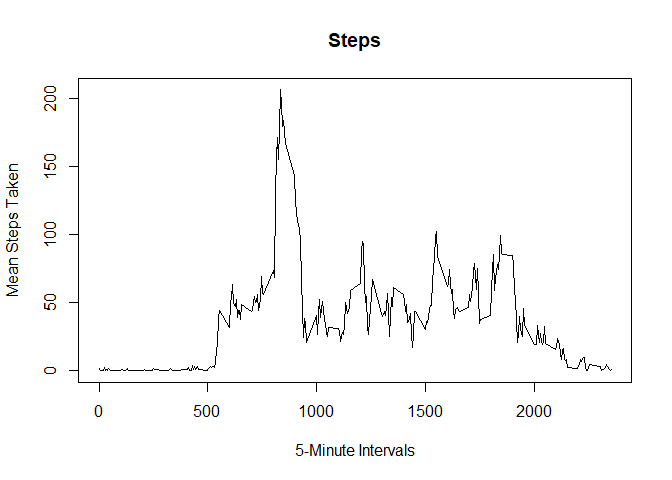

```r
colnames(stepsMean)=c("interval","steps")
plot(stepsMean$interval, stepsMean$steps, type="l", xlab = "5-Minute Intervals", ylab="Mean Steps Taken", main="Steps")
```

To find the interval that on average had the maximum number of steps we use this code:

```r
stepsMean$interval[which.max(stepsMean$steps)]
```

```
## [1] 835
```

## Imputing missing values

To find the total number of rows that are missing we can use this code:

```r
sum(is.na(data))
```

```
## [1] 2304
```

We can replace these values with the mean of the five minute interval of the row with the missing data.

As we are making edits with the original dataframe, we should make a copy of it.

```r
dataCopy = data
```

We can now calculate the missing values:

```r
missingMeans = by(data$steps,data$interval,mean,na.rm=TRUE)
```

Now we can match up the intervals and replace the missing values

```r
dataCopy[is.na(dataCopy),1] = missingMeans[as.character(dataCopy[is.na(dataCopy),3])]
```

Now we can redo some of the earlier calculations but for the new dataframe.

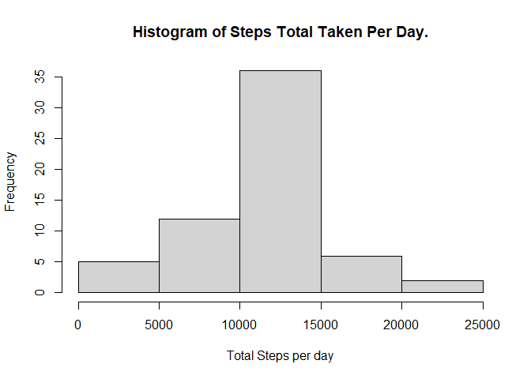

```r
#get the total steps per day and make a histogram
stepsPerDay2 = aggregate(dataCopy$steps,by=list(dataCopy$date),sum,na.rm=TRUE)
colnames(stepsPerDay2)=c("Date", "sum")
hist(stepsPerDay2$sum, xlab="Total Steps per day", main="Histogram of Steps Total Taken Per Day.")
```

```r
#mean and median
mean(stepsPerDay2$sum)
```

```
## [1] 10766.19
```

```r
median(stepsPerDay2$sum)
```

```
## [1] 10766.19
```

## Are there differences in activity patterns between weekdays and weekends?

First we should get the days of the week out of the Date

```r
dotw = weekdays(as.Date(dataCopy$date))
```

Now we can divide this into two, weekends and weekdays

```r
weekends=(dotw=="Saturday" | dotw=="Sunday")
dotw[weekends] = "Weekend"
dotw[!weekends] = "Weekday"
```

Now we should add this info to the dataframe, we’ll use dataCopy as we are changing the dataframe.

```r
dataCopy$dotw=factor(dotw)
```

Now we can create our panel plot. We need to get the mean number of steps by if it is a weekend or weekday and by interval

```r
sumMeans = aggregate(dataCopy$steps,by=list(dataCopy$interval, dataCopy$dotw),mean)
```

Now we can finally plot it! First add column names, however.

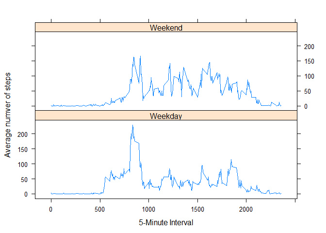

```r
colnames(sumMeans)=c("interval","dayType","steps")

library(lattice)

xyplot(sumMeans$steps ~ sumMeans$interval|sumMeans$dayType,sumMeans,type="l",layout=c(1,2), xlab ="5-Minute Interval", ylab="Average numver of steps")
```